# Monmouth Beach School District — NJ School Data Almanac – NJ District Profiles

NJ School Data Almanac

Monmouth Beach School District

MONMOUTH COUNTY · TRADITIONAL PUBLIC DISTRICT · DFG I · 224 STUDENTS (2026)

224

Students

79.1%

Gr 3-8 ELA

9%

Chronically absent

$23,997

Per pupil

*7 things the data says about Monmouth Beach School District. Every figure is computed from New Jersey Department of Education data via the njschooldata package — nothing is estimated. Comparisons use District Factor Group (DFG) peers (103 districts in DFG I).*

No. 1 ACHIEVEMENT

## Monmouth Beach Reading Proficiency Slid From 86.8% to 79.1% as the Post-COVID Recovery Stalled

After holding steady through the pandemic, the K-8 district’s NJSLA English scores have drifted down three straight reports to their lowest point on record.

Monmouth Beach was one of the rare districts whose reading scores barely flinched during the pandemic. On the NJSLA English exam for grades 3-8, proficiency stood at 86.8% in 2019, dipped only 2.4 points to 84.4% in 2022, and looked, on paper, like a school that had weathered the disruption better than most.

The slide came afterward. English proficiency eased to 83.7% in 2023 and then to 79.1% in 2024, the district’s lowest figure in the available record and nearly eight points below the 2019 peak. Math has followed a choppier path: 74.8% proficient in 2019, a dip to 70.7% in 2022, a rebound to 77.0% in 2023, and then a drop back to 70.9% in 2024.

In a district testing only a few dozen children per grade, a handful of students can move the percentage several points, so a single down year is noise. Three consecutive declines in English is a pattern. The question the data raises but cannot answer is whether the 2024 dip reflects a particular small cohort moving through, or an erosion in early literacy that the district will need to reverse before it compounds.

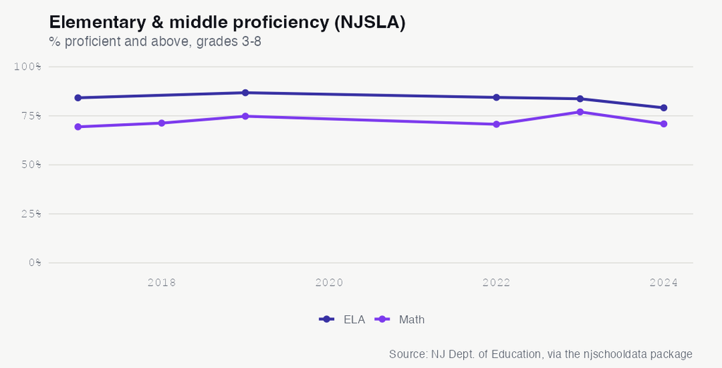

See the underlying data ›

No. 2 EQUITY

## A 24-Point Gender Gap: 86.8% of Monmouth Beach Girls Are Proficient in Reading, vs 63.2% of Boys

On the 2024 NJSLA English exam, the district’s girls outscored its boys by nearly 24 percentage points, one of its starkest internal divides.

Boys trailing girls in reading is a national pattern, but in Monmouth Beach the 2024 gap is unusually wide. On the NJSLA English exam for grades 3-8, 86.8% of the district’s girls scored proficient or above, compared with 63.2% of boys, a spread of 23.6 percentage points. The district as a whole came in at 79.1%, meaning the overall number is buoyed by its girls and dragged down by its boys.

The gap is large enough that it, more than any districtwide average, defines where Monmouth Beach’s reading challenge sits. With only a few dozen test-takers per grade, the boys’ figure rests on a small group of students, and a single struggling cohort can widen the divide. But the direction is unambiguous, and it aligns with a districtwide English score that has fallen three reports running.

Whether this is a durable gap or an artifact of one small class moving through the building is the open question. Either way, it points the district’s attention to a specific group of students rather than an abstract average.

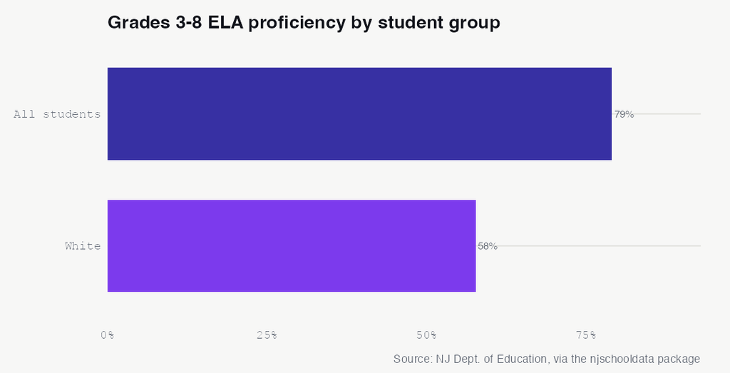

See the underlying data ›

No. 3 FINANCE

## Monmouth Beach Spends $23,997 Per Pupil, Up 72% Since 2014, as Enrollment Hits a Record Low

Per-pupil spending sits in the 83rd percentile among the state’s most affluent districts, even as the number of students the district serves keeps shrinking.

Monmouth Beach spent $23,997 per pupil in 2024, well above the $20,613 median for its District Factor Group I peers, the most affluent tier in New Jersey. That places the district in the 83rd percentile of its 103-district peer group.

That combination, rising spending over a smaller student body, is familiar arithmetic for tiny districts: a building, a staff roster, and fixed operating costs get divided across fewer children, pushing the per-pupil figure up. With enrollment now at a record-low 224, the question for the board is whether per-pupil costs keep climbing simply because the denominator keeps falling.

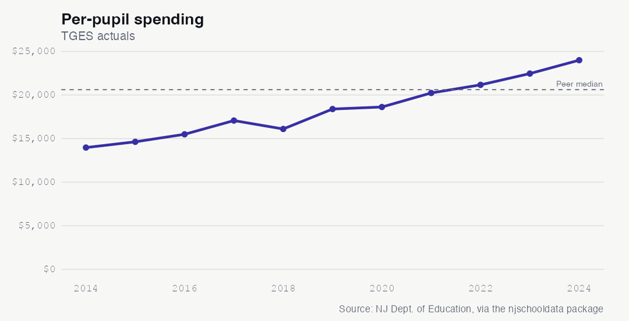

See the underlying data ›

No. 4 ENROLLMENT

## After a Pandemic Rebound, Monmouth Beach Enrollment Falls to a Record-Low 224

The shore K-8 district gained students during COVID, then lost 34 in two years to reach its smallest enrollment on record.

Most New Jersey districts shrank during the pandemic. Monmouth Beach did the opposite. Between 2019 and 2022, enrollment in this Monmouth County K-8 district rose from 234 to 250, a 6.8% gain, even as families left crowded classrooms elsewhere. By 2024 the district had climbed back to 258 students.

The rebound did not last. Enrollment dropped to 230 in 2025 and 224 in 2026, a loss of 34 students in two years, leaving the district at its lowest count on record. Since the 2015 peak of 266, Monmouth Beach has shed 42 students overall, a 15.8% decline.

In a district this small, a single departing family of three moves the headcount by more than a percentage point, so these swings look dramatic on paper. The reversal raises a question the enrollment table alone cannot answer: was the pandemic bump a temporary inflow of families seeking a small shore district, and is the recent slide a return to a longer downward trend, or the start of something steeper?

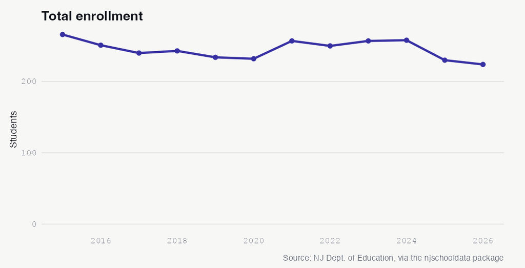

See the underlying data ›

No. 5 DEMOGRAPHICS

## Once 97.7% White, Monmouth Beach Is Now 90.6% as Hispanic and Multiracial Students Arrive

The district’s white enrollment share fell 7.1 points since 2015 while Hispanic enrollment grew and its first Black and multiracial students appeared.

In 2015, Monmouth Beach was among the least diverse districts in the state: 97.7% of its students were white, with a single-digit handful identifying as Hispanic or Asian. A decade later, the white share has fallen to 90.6%, a drop of 7.1 percentage points and the largest demographic shift in the district.

The change has come mostly from a growing Hispanic enrollment, up from 0.4% in 2015 to 6.2% in 2026, a 5.9-point increase. The district also recorded multiracial students for the first time during this period, reaching 4.3% in 2023 before settling at 1.3% in 2026, and its Black enrollment share rose to 1.8% in 2026 from zero in earlier years. Asian enrollment, meanwhile, slipped from 1.9% to none.

In a district of roughly 224 students, each percentage point represents only two or three children, so these shares move sharply year to year. Still, the trend line is consistent: a historically homogeneous shore district is slowly becoming less so. Whether that gradual diversification continues will depend on who moves into a town where overall enrollment is shrinking.

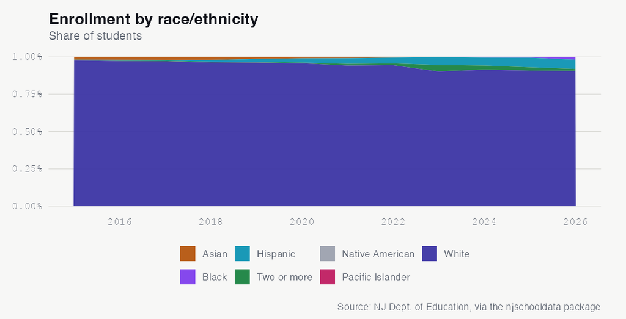

See the underlying data ›

No. 6 ATTENDANCE

## Chronic Absence in Monmouth Beach More Than Doubled Since 2019, to 9% in 2024

The share of students who are chronically absent rose from 4.1% before the pandemic to 9% in 2024, edging above the peer median after a 15.7% spike.

Before the pandemic, Monmouth Beach had little trouble keeping students in school: just 4.1% were chronically absent in 2019, meaning they missed 10% or more of the school year. By 2024 that figure had more than doubled to 9%, slightly above the 7.8% median for its DFG I peers.

The path there was turbulent. Chronic absence dipped to 2.5% in 2021, a year of disrupted schedules, then surged to 9.8% in 2022 and 15.7% in 2023, the district’s high-water mark, before falling back to 9% in 2024. That kind of volatility is amplified in a district this small, where a few students with extended absences can swing the rate by several points.

The 2024 figure is still well above the pre-pandemic baseline. Whether the decline from the 2023 peak marks a return toward the district’s old attendance norms, or a plateau at a permanently higher level, is the open question the data leaves for the year ahead.

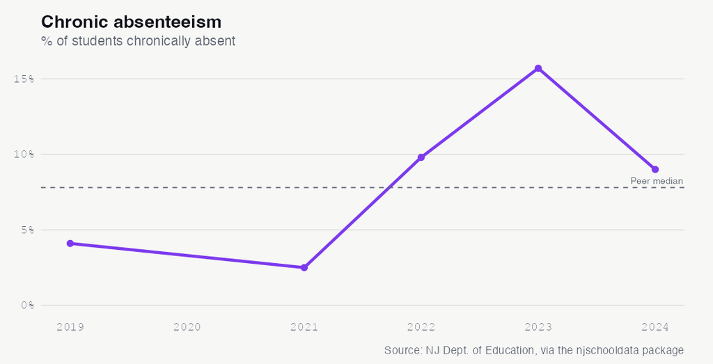

See the underlying data ›

No. 7 EQUITY

## Almost No Monmouth Beach Students Qualify for Subsidized Lunch or English Help

Across a full decade, free- and reduced-price lunch and English-learner counts have hovered at or near zero, underscoring the district’s affluence.

In most New Jersey districts, the share of students who are economically disadvantaged is one of the most consequential numbers on the report card. In Monmouth Beach, it is essentially nonexistent. The district reported a single student qualifying for free or reduced-price lunch in 2015 and zero in every year since, through 2026.

English learners are nearly as rare. The count of students classified as limited English proficient has never exceeded two in any year, peaking at two in 2021 and sitting at zero in 2026. This is consistent with the district’s standing in District Factor Group I, New Jersey’s highest socioeconomic tier.

The near-total absence of these populations means Monmouth Beach educates almost no students who face the economic and language barriers that drive outcomes in much of the state. It also means the district has little institutional experience serving them, a quiet consideration as its enrollment slowly diversifies along racial and ethnic lines.

See the underlying data ›

## The Almanac

The full longitudinal record behind the stories above. Every number a reader can check.

### Enrollment (total)

| year | students | yoy | yoy_pct |
| --- | --- | --- | --- |
| 2015 | 266 | NA | NA |
| 2016 | 251 | -15 | -5.6 |
| 2017 | 240 | -11 | -4.4 |
| 2018 | 243 | 3 | 1.2 |
| 2019 | 234 | -9 | -3.7 |
| 2020 | 232 | -2 | -0.9 |
| 2021 | 257 | 25 | 10.8 |
| 2022 | 250 | -7 | -2.7 |
| 2023 | 257 | 7 | 2.8 |
| 2024 | 258 | 1 | 0.4 |
| 2025 | 230 | -28 | -10.9 |
| 2026 | 224 | -6 | -2.6 |

### Demographic share (%) by year

| end_year | white | black | hispanic | asian | native_american | pacific_islander | multiracial |
| --- | --- | --- | --- | --- | --- | --- | --- |
| 2015 | 97.7 | 0 | 0.4 | 1.9 | 0 | 0 | 0 |
| 2016 | 97.2 | 0 | 0.4 | 2 | 0 | 0 | 0.4 |
| 2017 | 97.1 | 0 | 0.4 | 2.1 | 0 | 0 | 0.4 |
| 2018 | 96.3 | 0 | 1.2 | 2.1 | 0 | 0 | 0.4 |
| 2019 | 96.2 | 0 | 2.1 | 1.3 | 0 | 0 | 0.4 |
| 2020 | 95.7 | 0 | 3 | 0.9 | 0 | 0 | 0.4 |
| 2021 | 94.2 | 0 | 3.9 | 0.8 | 0 | 0 | 1.2 |
| 2022 | 94.4 | 0 | 4 | 0.4 | 0 | 0 | 1.2 |
| 2023 | 90.3 | 0 | 5.4 | 0 | 0 | 0 | 4.3 |
| 2024 | 91.5 | 0.4 | 5.4 | 0 | 0 | 0 | 2.7 |
| 2025 | 90.9 | 0.4 | 6.5 | 0 | 0 | 0 | 2.2 |
| 2026 | 90.6 | 1.8 | 6.2 | 0 | 0 | 0 | 1.3 |

### Special populations (LEP, FRL)

| end_year | subgroup | students | pct |
| --- | --- | --- | --- |
| 2015 | lep | 0 | 0.0 |
| 2015 | free_reduced_lunch | 1 | 0.4 |
| 2016 | lep | 0 | 0.0 |
| 2016 | free_reduced_lunch | 0 | 0.0 |
| 2017 | lep | 0 | 0.0 |
| 2017 | free_reduced_lunch | 0 | 0.0 |
| 2018 | lep | 1 | 0.4 |
| 2018 | free_reduced_lunch | 0 | 0.0 |
| 2019 | lep | 1 | 0.4 |
| 2019 | free_reduced_lunch | 0 | 0.0 |
| 2020 | lep | 1 | 0.4 |
| 2020 | free_reduced_lunch | 0 | 0.0 |
| 2021 | lep | 2 | 0.8 |
| 2021 | free_reduced_lunch | 0 | 0.0 |
| 2022 | lep | 0 | 0.0 |
| 2022 | free_reduced_lunch | 0 | 0.0 |
| 2023 | lep | 0 | 0.0 |
| 2023 | free_reduced_lunch | 0 | 0.0 |
| 2024 | lep | 0 | 0.0 |
| 2024 | free_reduced_lunch | 0 | 0.0 |
| 2025 | lep | 0 | 0.0 |
| 2025 | free_reduced_lunch | 0 | 0.0 |
| 2026 | lep | 0 | 0.0 |
| 2026 | free_reduced_lunch | 0 | 0.0 |

### NJSLA grades 3-8 proficiency (% proficient+, enrollment-weighted across grades)

| testing_year | test_name | prof |
| --- | --- | --- |
| 2017 | ela | 84.2 |
| 2017 | math | 69.4 |
| 2018 | math | 71.3 |
| 2019 | ela | 86.8 |
| 2019 | math | 74.8 |
| 2022 | ela | 84.4 |
| 2022 | math | 70.7 |
| 2023 | ela | 83.7 |
| 2023 | math | 77.0 |
| 2024 | ela | 79.1 |
| 2024 | math | 70.9 |

### NJSLA ELA proficiency by subgroup (2024, grades 3-8)

| subgroup | prof |
| --- | --- |
| female | 86.8 |
| total_population | 79.1 |
| male | 63.2 |
| white | 57.7 |
| non_ed | NA |

### Chronic absenteeism (% chronically absent)

| year | chronic_pct |
| --- | --- |
| 2019 | 4.1 |
| 2021 | 2.5 |
| 2022 | 9.8 |
| 2023 | 15.7 |
| 2024 | 9 |

### Disciplinary removals

[output not shown]

### Police notifications (incident counts)

| year | violence | weapons | vandalism | substances | hib | other |
| --- | --- | --- | --- | --- | --- | --- |
| 2019 | 0 | 0 | 0 | 0 | 0 | 0 |
| 2020 | NA | NA | NA | NA | NA | NA |
| 2021 | 0 | 0 | 0 | 0 | 0 | 0 |
| 2022 | 0 | 0 | 0 | 0 | 0 | 0 |
| 2023 | 0 | 0 | 0 | 0 | 0 | 0 |
| 2024 | 0 | 0 | 0 | 0 | 0 | 0 |

### HIB (harassment/intimidation/bullying) investigations

| end_year | alleged | confirmed |
| --- | --- | --- |
| 2019 | 2 | 1 |
| 2020 | 0 | 0 |
| 2021 | 2 | 0 |
| 2022 | 6 | 1 |
| 2023 | 3 | 1 |
| 2024 | 3 | 0 |

### Special education (raw rows; inspect for classification rate)

| end_year | district_id |
| --- | --- |
| 2024 | 3250 |

### Per-pupil spending (TGES actuals)

| year | per_pupil | rank | ade |
| --- | --- | --- | --- |
| 2014 | 13970 | 26 | 278 |
| 2015 | 14629 | 29 | 267 |
| 2016 | 15492 | 29 | 252 |
| 2017 | 17067 | 40 | 239 |
| 2018 | 16102 | 22 | 245 |
| 2019 | 18391 | 39 | 234 |
| 2020 | 18623 | 44 | 235 |
| 2021 | 20236 | 47 | 256 |
| 2022 | 21165 | 46 | 253 |
| 2023 | 22461 | 46 | 256 |
| 2024 | 23997 | 50 | 257 |

### Spending composition shares (2025)

| classroom_share | support_services_share | administration_share | plant_ops_share | food_service_share | extracurricular_share | equipment_share |
| --- | --- | --- | --- | --- | --- | --- |
| 61.4 | 16.3 | 9.6 | 10.9 | NA | 1.5 | 0 |

### Staffing ratios

| end_year | student_teacher_district | student_admin_district | student_counselor_district | student_nurse_district |
| --- | --- | --- | --- | --- |
| 2024 | 8:1 | 64:1 | 257:1 | 257:1 |

Back to top